# R Notebook

## Linear Regression

### names of columns

```r
names(College)
```

```
 [1] "Private"     "Apps"        "Accept"      "Enroll"      "Top10perc"   "Top25perc"   "F.Undergrad" "P.Undergrad"
 [9] "Outstate"    "Room.Board"  "Books"       "Personal"    "PhD"         "Terminal"    "S.F.Ratio"   "perc.alumni"
[17] "Expend"      "Grad.Rate"
```

### Creating the model

```r
College_lm <- lm(Apps ~ Private + Accept + Enroll + Top10perc + Top25perc + F.Undergrad + P.Undergrad + Outstate + Room.Board + Books + Personal + PhD + Terminal + S.F.Ratio + perc.alumni + Expend + Grad.Rate ,
                data = College_Training)
```

### summary of the model

```r
summary(College_lm)
```

```
Call:
lm(formula = Apps ~ Private + Accept + Enroll + Top10perc + Top25perc +
    F.Undergrad + P.Undergrad + Outstate + Room.Board + Books +
    Personal + PhD + Terminal + S.F.Ratio + perc.alumni + Expend +
    Grad.Rate, data = College_Training)

Residuals:
    Min      1Q  Median      3Q     Max
-2079.1  -302.9   -65.7   224.8  5297.4

Coefficients:
              Estimate Std. Error t value Pr(>|t|)
(Intercept) -350.51824  607.32513  -0.577  0.56444
PrivateYes  -529.47879  226.98075  -2.333  0.02059 *
Accept         1.14459    0.09039  12.663  < 2e-16 ***
Enroll        -0.90966    0.30695  -2.964  0.00338 **
Top10perc     20.30574    7.63359   2.660  0.00840 **
Top25perc     -2.11979    6.26059  -0.339  0.73525
F.Undergrad    0.25843    0.04919   5.254 3.58e-07 ***
P.Undergrad   -0.02107    0.05725  -0.368  0.71326
Outstate      -0.02282    0.02609  -0.875  0.38273
Room.Board     0.21272    0.06646   3.201  0.00158 **
Books         -0.23137    0.30872  -0.749  0.45441
Personal       0.09989    0.10463   0.955  0.34080
PhD           -0.64808    7.30928  -0.089  0.92943
Terminal      -9.61990    8.15239  -1.180  0.23930
S.F.Ratio    -12.73559   21.95664  -0.580  0.56250
perc.alumni   -5.32103    6.02583  -0.883  0.37820
Expend         0.07267    0.01728   4.206 3.82e-05 ***
Grad.Rate      5.75830    4.22654   1.362  0.17449
---
Signif. codes:  0 ‘***’ 0.001 ‘**’ 0.01 ‘*’ 0.05 ‘.’ 0.1 ‘ ’ 1

Residual standard error: 777 on 215 degrees of freedom
Multiple R-squared:  0.9398,    Adjusted R-squared:  0.9351
F-statistic: 197.6 on 17 and 215 DF,  p-value: < 2.2e-16
```

*OBSERVATION:* The Residual standard error of the model of train set is 777,Multiple R-squared: 0.9398 and Adjusted R-squared: 0.9351

### Make predictions using the test data

```r
x_test <- model.matrix(Apps ~ Private + Accept + Enroll + Top10perc + Top25perc + F.Undergrad + P.Undergrad + Outstate + Room.Board + Books + Personal + PhD + Terminal + S.F.Ratio + perc.alumni + Expend + Grad.Rate , College_Test)[,-1]
y_test <- College_Test$App
```

### Generate predictions

```r
lm.pred <- predict(College_lm, newx = x.test)
```

### Compute the Test MSE

```r
mean((lm.pred - y.test)^2)
```

[output not shown]

*OBSERVATION*: Computed Test MSE is 24372410,this is too big hence our model did not perform well. 3. Fit a ridge regression model on the training set, with λ chosen by cross-validation. Report the test error obtained ## Creating the model matrix

```r
x <- model.matrix(Apps ~ Private + Accept + Enroll + Top10perc + Top25perc + F.Undergrad + P.Undergrad + Outstate + Room.Board + Books + Personal + PhD + Terminal + S.F.Ratio + perc.alumni + Expend + Grad.Rate , College_Training)[,-1]
y <- College_Training$Apps
```

## 2. Create a grid of values over which the ridge regression models need to be built and create ridge.mod

```r
grid <- 10^seq(10,-2, length = 100)

# If alpha=0 then a ridge regression model is fit, and if alpha=1 then a lasso model is fit. We first fit a ridge regression model. We pass the x, y, alpha and lambda values

ridge.mod <- glmnet(x, y, alpha = 0, lambda = grid)
```

## Select the best $\lambda$

We use cross *Cross-Validation* to identify the best $\lambda$

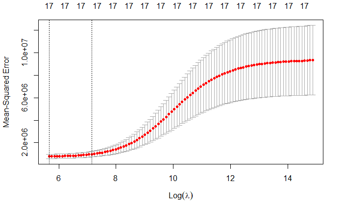

```r
set.seed(11)
cv.ridge <- cv.glmnet(x, y, alpha = 0)
plot(cv.ridge)
```

```r
bestlambda <- cv.ridge$lambda.min
bestlambda
```

```
[1] 286.9712
```

```r
x.test <- model.matrix(Apps ~ Private + Accept + Enroll + Top10perc + Top25perc + F.Undergrad + P.Undergrad + Outstate + Room.Board + Books + Personal + PhD + Terminal + S.F.Ratio + perc.alumni + Expend + Grad.Rate , College_Training)[,-1]
y.test <- College_Training$Apps
```